### ECE 225B: Universal Probability and Applications @UCSD

http://circuit.ucsd.edu/~yhk/ece225b-spr18/

# Homework 3: Universal portfolios

- **Due: June 4, 2018, 11:59 PM**
- Late homework will never be accepted.
- The homework will be collected through Gradescope. Please follow the submission instruction on Piazza.
- Please read the following problems carefully, and **write down your code as clearly as possible and add suitable comments.**
- **NAME**:
- **PID**:

In this homework, we will implement the Universal Portfolio algorithm by Cover.

> [1] Cover, Thomas M. **"Universal Portfolios."** *Mathematical Finance* 1.1 (1991): 1-29.

> [2] Blum, Avrim, and Adam Kalai. **"Universal portfolios with and without transaction costs."** *Machine Learning* 35.3 (1999): 193-205.

> [3] Kalai, Adam, and Santosh Vempala. **"Efficient algorithms for universal portfolios."** *Journal of Machine Learning Research* 3.Nov (2002): 423-440.

> [4] Cover, Thomas M., and Joy A. Thomas. **Elements of information theory**. John Wiley & Sons, 2012.

## Review

### 1) Constant rebalanced portfolio as a probability induced portfolio

Let $m$ be the number of stocks of our interest. Recall that a probability induced portfolio gives us a "fund of funds" strategy, which is a mixture of all extremal strategies. More precisely, let $\mathrm{a}=\mathrm{a}_p$ be the portfolio induced by a pmf $p$. Then, $$ \mathrm{a}_{ij}(\mathrm{\mathbf{x}}^{i-1}) =\frac{ \displaystyle\sum_{y^{i-1}}p(j|y^{i-1})\mathrm{\mathbf{x}}(y^{i-1})p(y^{i-1}) }{ \displaystyle\sum_{y^{i-1}}p(y^{i-1})\mathrm{\mathbf{x}}(y^{i-1}) }. $$ A constant rebalanced portfolio (CRP) with $\theta=(\theta_1,\ldots,\theta_m)\in\Delta^{m-1}$ is induced by an iid probability $p_{\theta}(y^n)=\prod_{i=1}^n p_{\theta}(y_i)$, where $p_{\theta}(y)=\theta_y$ for $y\in[m]$.

### 2) Cover's Universal Portfolio algorithm

To compete with the class of CRPs, let's consider a mixture strategy. For a density $w(\theta)$ of $\theta$ over the simplex $\Delta^{m-1}$, we consider $$ q_w(y^n)=\int_{\Delta^{m-1}} p_{\theta}(y^n)w(\theta)d\theta. $$ Then, we have $$ \mathrm{b}_{ij}(\mathrm{\mathbf{x}}^{i-1}) =\frac{ \displaystyle\int \theta_j \mathbf{S}_{i-1}(\theta,\mathbf{x}^{i-1})w(\theta)d\theta }{ \displaystyle\int \mathbf{S}_{i-1}(\theta,\mathbf{x}^{i-1})w(\theta)d\theta }, $$ and further $$ \mathbf{S}_n(\mathrm{b},\mathbf{x}^n)=\int \mathbf{S}_n(\theta,\mathbf{x}^n)w(\theta)d\theta. $$ In other words, this mixture strategy is equivalent to investing your money over the simplex *continuously* according to the weight $w(\theta)$. In particular, **Cover's Universal Portfolio ($\mathsf{UP}$) algorithm** is using $\mathsf{Dirichlet}(1/2,\ldots,1/2)$ prior for the density (or weight) $w(\theta)$. In general, let's call $\mathsf{UP}(\alpha)$ algorithm for the mixture startegy with $\mathsf{Dirichlet}(\alpha,\ldots,\alpha)$ prior.

### 3) Implementation

Note that, however, the exact integration is computationally difficult. Hence, in this homework, we approximate the integration by Monte-Carlo sampling as follows. $$ \mathbf{S}_n(\mathrm{b},\mathbf{x}^n)\approx \frac{1}{N}\sum_{k=1}^N \mathbf{S}_n(\theta_k,\mathbf{x}^n). $$

- For $N$ sufficiently large, draw $N$ probability vectors $\theta(1),\ldots,\theta(N)\in\Delta^{m-1}$, each of which corresponds to a CRP, according to the Dirichlet prior.
- Divide your money equally to those CRPs, and hold.

```python
import numpy as np
import pandas as pd  # pandas data frame
import os            # to access the file directories
import matplotlib.pyplot as plt
%matplotlib inline
%pylab inline

pylab.rcParams['figure.figsize'] = (15, 6)
font = {'family' : 'serif',
        'weight' : 'normal',
        'size'   : 12}
matplotlib.rc('font', **font)
```

## The stock data

```python
stock_name_dict = {'A': 'Agilent Technologies, Inc.',
                   'B': 'Barnes Group Inc.',
                   'C': 'Citigroup Inc.',
                   'D': 'Dominion Energy, Inc.',
                   'F': 'Ford Motor Company',
                   'M': 'Macy\'s, Inc.',
                   'S': 'Sprint Corporation',
                   'T': 'AT&T Inc.',
                   'X': 'United States Steel Corporation',
                   'Y': 'Alleghany Corporation'}
```

The following code preprocesses the historical data.

```python
directory = 'data/'
stocks_dict = {}
prices_dict = {}
price_relatives_dict = {}
for filename in os.listdir(directory):
    if filename.endswith(".csv"):
        df = pd.read_csv(directory+filename)
        stock_symbol = os.path.splitext(filename)[0]

        temp_dict = {}
        temp_dict['Name'] = stock_name_dict[stock_symbol]
        temp_dict['Close'] = np.array(df['Close'])
        temp_dict['Relative'] = np.array(df['Close']/df['Open'])

        stocks_dict[stock_symbol] = temp_dict
    else:
        continue
```

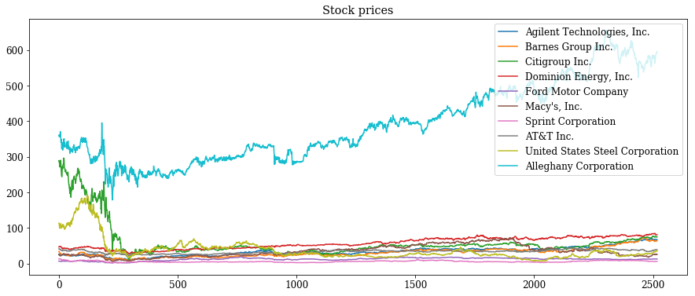

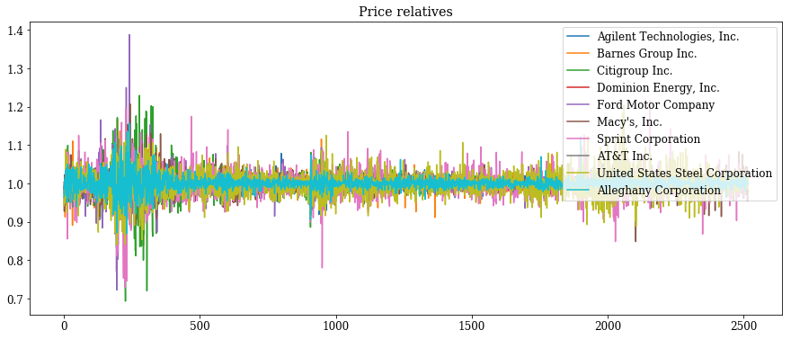

```python
for key in stocks_dict:
    plt.plot(stocks_dict[key]['Close'], label=stocks_dict[key]['Name'])
plt.legend(loc=1)
plt.title(r'Stock prices');

plt.figure()
for key in stocks_dict:
    plt.plot(stocks_dict[key]['Relative'], label=stocks_dict[key]['Name'])
plt.legend(loc=1)
plt.title(r'Price relatives');
```

```python
prices_stack = np.vstack([stocks_dict[k]['Close'] for k in sorted(stocks_dict.keys())])
price_relatives_stack = np.vstack([stocks_dict[k]['Relative'] for k in sorted(stocks_dict.keys())])
```

## Problem 1. (Approximate optimal CRP in hindsight)

In this problem, we find the optimal CRP *in hindsight* given the price relatives. Again, as the exact optimization is hard, we will perform a Monte Carlo search by sampling random points uniformly over the simplex. (It is okay to implement a grid search if you wish.)

Write a function

```
approx_optimal_CRP(price_relatives_stack, N)
```

which takes `price_relatives_stack` and `N` the number of random samples as inputs, and outputs

- the optimal CRP (i.e., the optimal probability vector), and
- the optimal wealth achieved by the CRP.

**Hint**: The $\mathsf{Dirichlet}(1,\ldots,1)$ is the uniform distribution over the simplex, and `np.random.dirichlet` generates a Dirichlet random vector. By the way, can you sample a point uniformly at random from the simplex without using the predifined Dirichlet sampling?

```python
def invest_with_CRP(a_CRP, price_relatives_stack):
    assert len(a_CRP) == len(price_relatives_stack)
    return np.prod(np.dot(a_CRP, price_relatives_stack))
```

```python
def approx_optimal_CRP(price_relatives_stack, N):
    """
    Given price relative vectors, find an approximate optimal CRP
    by Monte Carlo sampling of CRP over the simplex uniformly at random.
    """
    num_stocks = price_relatives_stack.shape[0]
    sampled_CRPs = [np.random.dirichlet([1]*num_stocks) for __ in range(N)]  # uniformly sampled over the simplex
    sampled_CRPs = sorted(sampled_CRPs, key=lambda x: x[0])
    return_rate_list = [invest_with_CRP(CRP, price_relatives_stack) for CRP in sampled_CRPs]

    approx_opt_CRP_idx = argmax(return_rate_list)
    if return_rate_list[approx_opt_CRP_idx] > 1:
        plt.plot([1-CRP[0] for CRP in sampled_CRPs], return_rate_list, marker="*")

    return sampled_CRPs[approx_opt_CRP_idx], return_rate_list[approx_opt_CRP_idx]
```

## Problem 2. (Approximate Universal Portfolio algorithm)

In this problem, we implemet the approximate Universal Portfolio algorithm $\mathsf{UP}(\alpha)$.

Write a function

```
approx_UP(price_relatives_stack, N, alpha)
```

that takes

- `price_relatives_stack`,
- `alpha` the parameter for the $\mathsf{Dirichlet}$ prior, and
- `N` the number of random samples drawn from the $\mathsf{Dirichlet}(\alpha,\ldots,\alpha)$ prior

as inputs, and outputs

- the wealth ratio achieved by the UP.

```python
def approx_UP(price_relatives_stack, alpha=1/2, N=100):
    """
    N: number of CRPs drawn from alpha
    alpha: a parpameter for Dirichlet(alpha,...,alpha) prior
    """
    num_stocks = price_relatives_stack.shape[0]
    sampled_CRPs = [np.random.dirichlet([alpha]*num_stocks) for __ in range(N)]
    return_rate_list = [invest_with_CRP(CRP, price_relatives_stack) for CRP in sampled_CRPs]

    num_days = price_relatives_stack.shape[1]
    b_UP = np.zeros(price_relatives_stack.shape)

    for t in range(num_days):
        return_rate_list_t = [invest_with_CRP(CRP, price_relatives_stack[:, :t]) for CRP in sampled_CRPs]
        for k, CRP in enumerate(sampled_CRPs):
            b_UP[:, t] += CRP * return_rate_list_t[k]
        b_UP[:, t] /= sum(return_rate_list_t)

    return np.mean(return_rate_list), b_UP
```

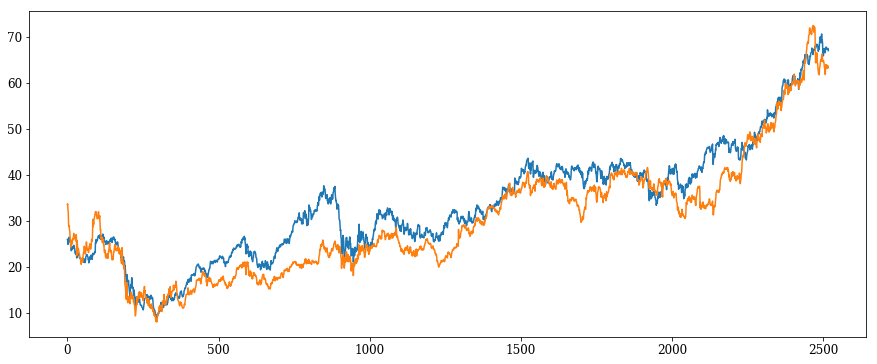

```python
plt.plot(np.transpose(prices_stack[(0,1), :]))
```

```
Wall time: 10.1 s
```

```
(array([7.93127792e-01, 2.06863282e-01, 8.92595149e-06]), 4.465356404129358)
```

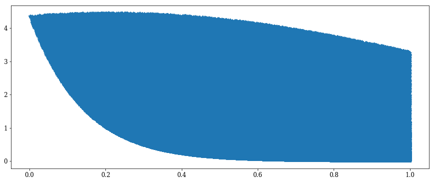

```python
%time approx_optimal_CRP(price_relatives_stack[(0,1,2), :], N=500000)
```

```python
%time approx_UP(price_relatives_stack[(0,1),:], N=1000, alpha=0.5)
```

```
Wall time: 30.7 s
```

```
(4.059432161074425,
 array([[0.50271361, 0.50108446, 0.49933109, ..., 0.53650511, 0.53630791,
         0.53634435],
        [0.49728639, 0.49891554, 0.50066891, ..., 0.46349489, 0.46369209,
         0.46365565]]))
```

```python
b_UP = _[1]
```

```python
b_UP
```

[output not shown]

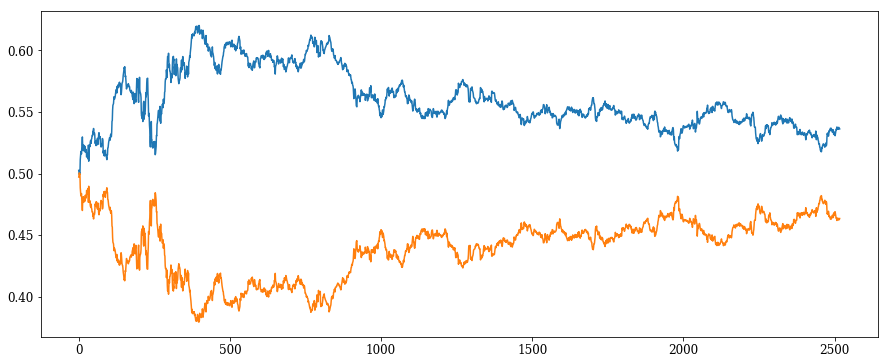

```python
plt.plot(b_UP[0])
plt.plot(b_UP[1])
```

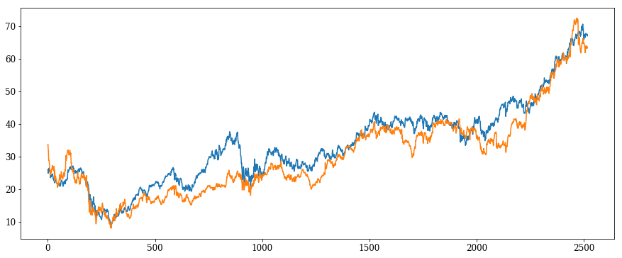

```python
plt.plot(prices_stack[0])
plt.plot(prices_stack[1])
```

```
(0, 1) 4.0529095695587705 4.465675328712097
(0, 2) 1.0570894674563118 4.32899846003565
(0, 3) 3.3766002188855455 4.36916281063263
(0, 4) 1.0869808634386162 4.3596953458441865
(0, 5) 2.052217215118657 4.362765949188257
(0, 6) 1.0956870419114644 4.332083136607008
(0, 7) 2.124001272366331 4.368963532237619
(0, 8) 1.2853187498953944 4.263733846189493
(0, 9) 3.188312225382015 4.368820778481182
(1, 2) 0.7582146162913356 3.282675863032962
(1, 3) 2.998499012658981 3.3687708572977444
(1, 4) 0.6873832944481592 3.129789007187662
(1, 5) 1.7254527296203863 3.2875990170171514
(1, 6) 0.8441957084107145 3.2400563510259905
(1, 7) 1.8561290001879047 3.284332860347145
(1, 8) 1.0217392383068304 3.2848530077155713
(1, 9) 2.792817240760202 3.2966632014245616
(2, 3) 0.5151777580706158 2.3220220686358624
```

[output not shown]

```
 0.6352772457794267 2.3239116834277325
(3, 7) 1.3868056905673263 2.330806020612513
(3, 8) 0.7186073775623206 2.3200884394147177
(3, 9) 2.2369220270717936 2.3977724870237305
(4, 9) 0.4536030409124963 1.9185672577702815
(5, 9) 1.2240939548688388 1.947617055623075
(6, 9) 0.5606042919228192 1.9117078032333024
(7, 9) 1.2462517708091545 1.9479921600219072
(8, 9) 0.624765123256832 1.9488397302975098
```

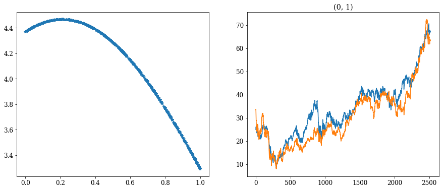

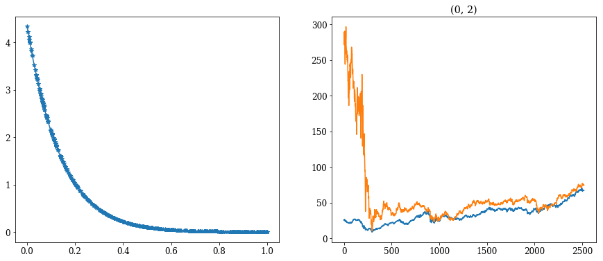

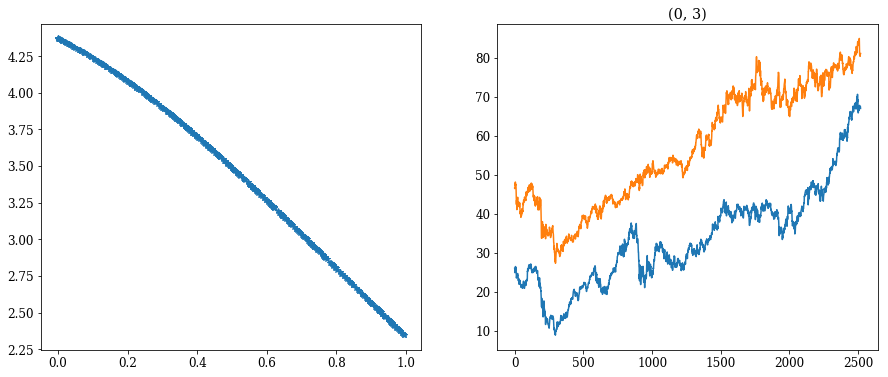

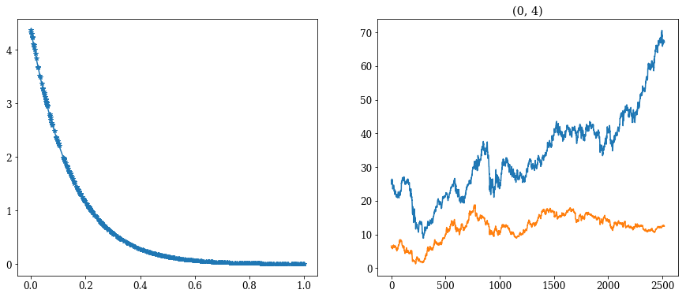

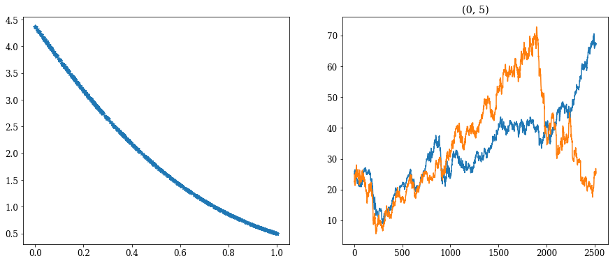

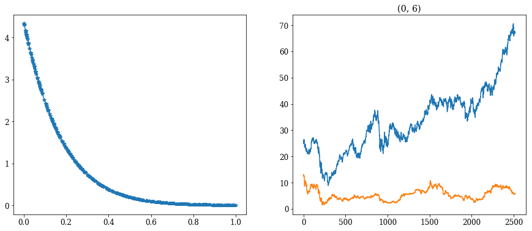

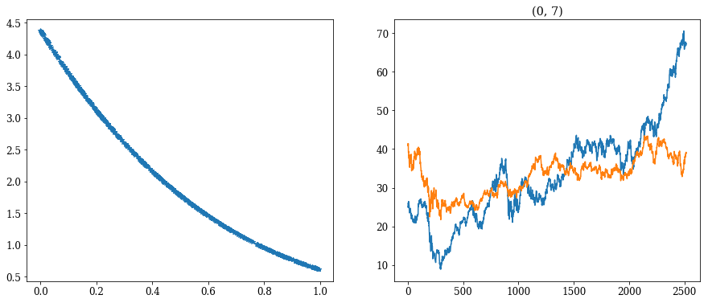

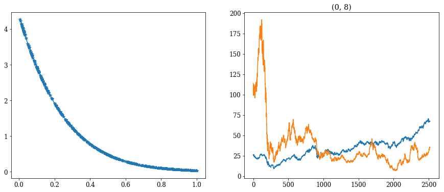

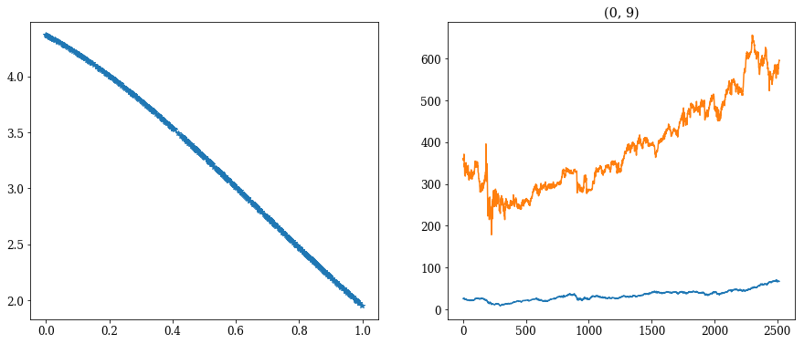

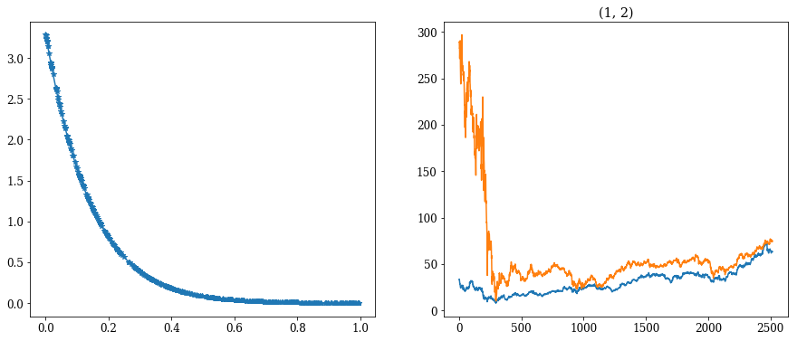

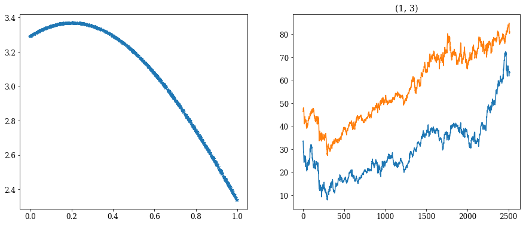

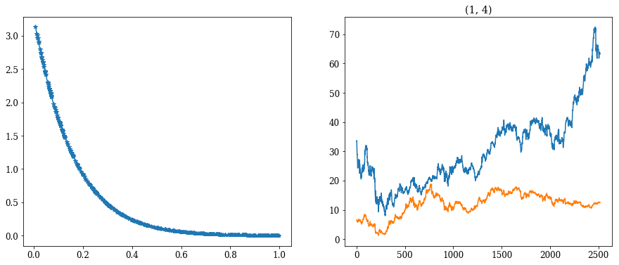

[18 more figures not shown]

```python
N=500
for i in range(len(stocks_dict)):
    for j in range(i+1, len(stocks_dict)):
        stock_indices = (i,j)
        return_UP = approx_UP(price_relatives_stack[stock_indices,:], N=N, alpha=0.5)
        plt.subplot(1,2,1)
        __, return_optimal_CRP = approx_optimal_CRP(price_relatives_stack[stock_indices, :], N=N)

        if return_optimal_CRP > 1:
            print(stock_indices, return_UP, return_optimal_CRP)
            plt.subplot(1,2,2)
            plt.plot(np.transpose(prices_stack[stock_indices, :]))
            plt.title(stock_indices)
            plt.figure()
```

```python
approx_UP(price_relatives_stack[0:4], N=100000, alpha=1/2)
```

[output not shown]

```python
a_CRP = np.random.dirichlet([1/2]*price_relatives_stack.shape[0])
invest_by_CRP(a_CRP, price_relatives_stack)
```

[output not shown]

## Problem 3. (Experiments)

Now based on our the implementations, we would like to check the performance of the $\mathsf{UP}$ algorithm compared to the optimal CRP using the real market data.

### Problem 3(a).

Choose any two stocks such that the performance of the CRP over the stocks looks as follows.

An image excerpted from "Elements of Information Theory" by Cover and Thomas [4].

[figure not shown]

Draw the same plot for the selected stocks, and draw horizontal lines of the performance of the UP algorithm for $\alpha\in\{0.1,0.2,\ldots,1\}$.

### Problem 3(b).

Repeat the previous experiment with three, four, and five stocks. For these high-dimensional problems, you do not have to plot the performance of the CRPs.

**NOTE**: Please ensure that you are using $N$ large enough to find a good approximate for the optimal values.

```python
'''Functions for drawing contours of Dirichlet distributions.'''

# Author: Thomas Boggs
# https://gist.github.com/tboggs/8778945
import numpy as np
import matplotlib.pyplot as plt
import matplotlib.tri as tri
from functools import reduce

_corners = np.array([[0, 0], [1, 0], [0.5, 0.75**0.5]])
_triangle = tri.Triangulation(_corners[:, 0], _corners[:, 1])
_midpoints = [(_corners[(i + 1) % 3] + _corners[(i + 2) % 3]) / 2.0 \
              for i in range(3)]

def xy2bc(xy, tol=1.e-3):
    '''Converts 2D Cartesian coordinates to barycentric.
    Arguments:
        `xy`: A length-2 sequence containing the x and y value.
    '''
    s = [(_corners[i] - _midpoints[i]).dot(xy - _midpoints[i]) / 0.75 \
         for i in range(3)]
    return np.clip(s, tol, 1.0 - tol)

class Dirichlet(object):
    def __init__(self, alpha):
        '''Creates Dirichlet distribution with parameter `alpha`.'''
        from math import gamma
        from operator import mul
        self._alpha = np.array(alpha)
        self._coef = gamma(np.sum(self._alpha)) / \
                     reduce(mul, [gamma(a) for a in self._alpha])
    def pdf(self, x):
        '''Returns pdf value for `x`.'''
        from operator import mul
        return self._coef * reduce(mul, [xx ** (aa - 1)
                                         for (xx, aa)in zip(x, self._alpha)])
    def sample(self, N):
        '''Generates a random sample of size `N`.'''
        return np.random.dirichlet(self._alpha, N)

def draw_pdf_contours(dist, border=False, nlevels=200, subdiv=8, **kwargs):
    '''Draws pdf contours over an equilateral triangle (2-simplex).
    Arguments:
        `dist`: A distribution instance with a `pdf` method.
        `border` (bool): If True, the simplex border is drawn.
        `nlevels` (int): Number of contours to draw.
        `subdiv` (int): Number of recursive mesh subdivisions to create.
        kwargs: Keyword args passed on to `plt.triplot`.
    '''
    from matplotlib import ticker, cm
    import math

    refiner = tri.UniformTriRefiner(_triangle)
    trimesh = refiner.refine_triangulation(subdiv=subdiv)
    pvals = [dist.pdf(xy2bc(xy)) for xy in zip(trimesh.x, trimesh.y)]

    plt.tricontourf(trimesh, pvals, nlevels, **kwargs)
    plt.axis('equal')
    plt.xlim(0, 1)
    plt.ylim(0, 0.75**0.5)
    plt.axis('off')
    if border is True:
        plt.hold(1)
        plt.triplot(_triangle, linewidth=1)

def plot_points(X, barycentric=True, border=True, **kwargs):
    '''Plots a set of points in the simplex.
    Arguments:
        `X` (ndarray): A 2xN array (if in Cartesian coords) or 3xN array
                       (if in barycentric coords) of points to plot.
        `barycentric` (bool): Indicates if `X` is in barycentric coords.
        `border` (bool): If True, the simplex border is drawn.
        kwargs: Keyword args passed on to `plt.plot`.
    '''
    if barycentric is True:
        X = X.dot(_corners)
    plt.plot(X[:, 0], X[:, 1], 'k.', ms=1, **kwargs)
    plt.axis('equal')
    plt.xlim(0, 1)
    plt.ylim(0, 0.75**0.5)
    plt.axis('off')
    if border is True:
        plt.hold(1)
        plt.triplot(_triangle, linewidth=1)

if __name__ == '__main__':
#     f = plt.figure(figsize=(8, 6))
#     alphas = [[0.999] * 3,
#               [5] * 3,
#               [2, 5, 15]]
    alphas = [[5] * 3]
    for (i, alpha) in enumerate(alphas):
        plt.subplot(2, len(alphas), i + 1)
        dist = Dirichlet(alpha)
        draw_pdf_contours(dist, cmap='hot')
        title = r'$\alpha$ = {}'.format(alpha)
        plt.title(title, fontdict={'fontsize': 12})
#         plt.subplot(2, len(alphas), i + 1 + len(alphas))
#         plot_points(dist.sample(5000))
    plt.savefig('dirichlet_plots.png')
    print('Wrote plots to "dirichlet_plots.png".')
```